# Презентация по лабораторной работе №13

Дисциплина: операционные системы

Лобанова П. И.

Российский университет дружбы народов, Москва, Россия

06.05.2023

# Информация

## Докладчик

- Лобанова Полина Иннокентьевна
- учащаяся факультета физико-математических и естественных наук
- учащаяся направления “Компьютерные и информационные науки”
- Российский университет дружбы народов
- polla-2004@mail.ru

# Цель работы

Приобрести простейшие навыки разработки, анализа, тестирования и отладки приложений в ОС типа UNIX/Linux на примере создания на языке программирования С калькулятора с простейшими функциями.

# Ход работы

## Создание программы

Первое, что нужно было сделать для создания калькулятора, это создание и заполнение всех необходимых файлов.

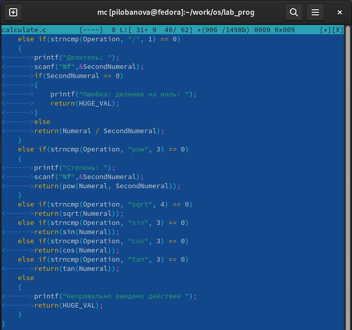

*Содержание одного из файлов.*

## Запуск программы

Далее, нужно было запустить скомпилированный файл через отладчик, чтобы проверить его работу.

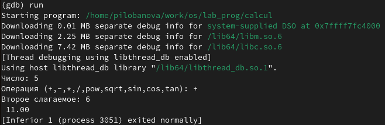

*Результат работы программы.*

## Работа с отладчиком

С помощью отладчика мы смогли увидеть исходный код (или же только нужные нам строки), установить точки останова и многое другое.

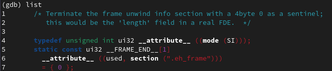

*Часть кода.*

## Анализ файлов

Последнее, что нам нужно было сделать, это проанализировать два файла с помощью команды splint.

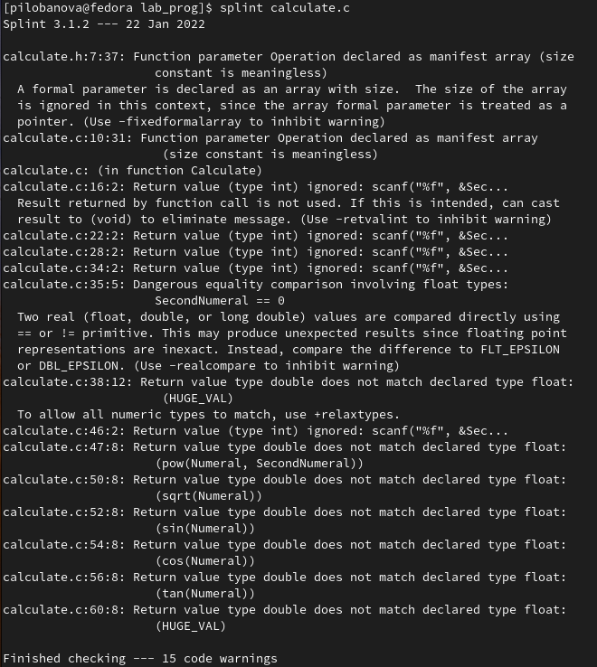

*Анализ одного из файлов.*

# Контрольные вопросы

1. Как получить информацию о возможностях программ gcc, make, gdb и др.?
2. Назовите и дайте краткую характеристику основным этапам разработки приложений в UNIX.
3. Что такое суффикс в контексте языка программирования? Приведите примеры использования.
4. Каково основное назначение компилятора языка С в UNIX?
5. Для чего предназначена утилита make?
6. Приведите пример структуры Makefile. Дайте характеристику основным элементам этого файла.

## Контрольные вопросы

7. Назовите основное свойство, присущее всем программам отладки. Что необходимо сделать, чтобы его можно было использовать?
8. Назовите и дайте основную характеристику основным командам отладчика gdb.
9. Опишите по шагам схему отладки программы, которую Вы использовали при выполнении лабораторной работы.
10. Прокомментируйте реакцию компилятора на синтаксические ошибки в программе при его первом запуске.
11. Назовите основные средства, повышающие понимание исходного кода программы.
12. Каковы основные задачи, решаемые программой splint?

# Вывод

Я приобрела простейшие навыки разработки, анализа, тестирования и отладки приложений в ОС типа UNIX/Linux на примере создания на языке программирования С калькулятора с простейшими функциями.